# Session 3 : Geoprocessing with vectors

```r
my.palette <- brewer.pal(n = 7, name = "OrRd")

library(classInt)
quantile(fraL2_temp$temp)
```

```
      0%      25%      50%      75%     100%
13.68853 23.14317 25.57279 28.12299 34.53361
```

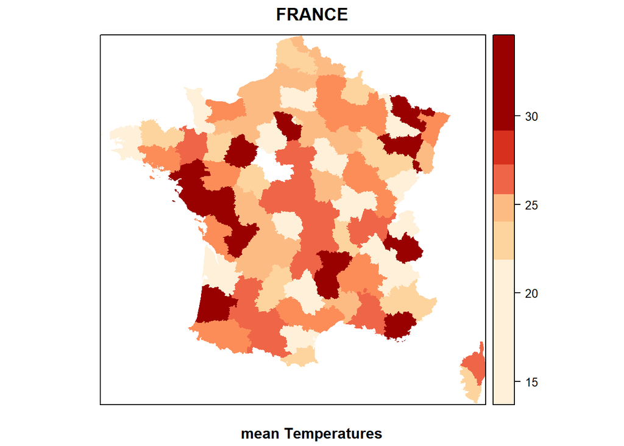

```r
breaks.qt <- classIntervals(fraL2_temp$temp, n = 6, style = "quantile", intervalClosure = "right")
spplot(fraL2_temp, "temp", main = "FRANCE", sub = "mean Temperatures", col = "transparent",  col.regions = my.palette,
       at = breaks.qt$brks)
```

With **terra** you can use the *plot* function to make maps. See ?plot and choose *terra* to get more informations. You can plot a quantitative map using *continuous*,*classes* or *interval* type.

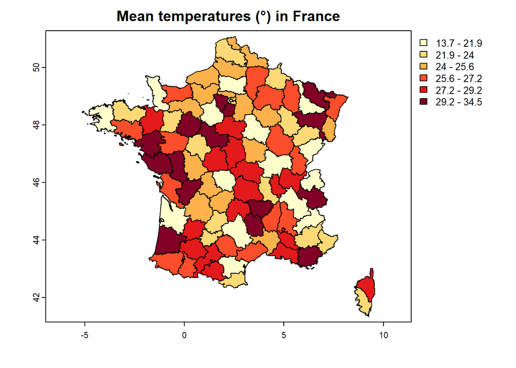

```r
my.palette <- brewer.pal(n = 9, name = "YlOrRd")

#Using terra function plot with interval
plot(fraL2_temp,"temp",type="interval",breaks=6,breakby="cases", col=my.palette,main="Mean temperatures (°) in France")
```

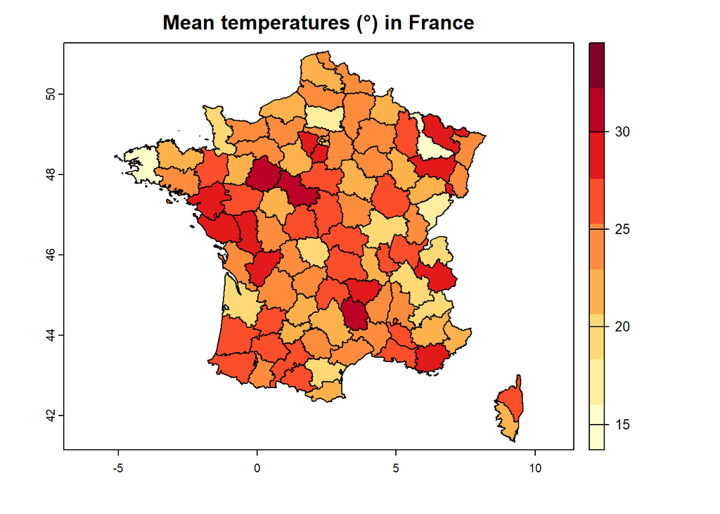

```r
#Using terra function plot with continuous values
plot(fraL2_temp,"temp",type="continuous", col=my.palette,main="Mean temperatures (°) in France")
```

### Geoprocessing with “sf”

Have a look to Chapter 4-5 of the book [Geocomputation in R](https://geocompr.robinlovelace.net/) and this [vignette](https://cran.r-project.org/web/packages/sf/vignettes/sf1.html). You can do similar geoprocessing operations using the functions “st_union”, “st_join”, “st_intersection”. Try to understand how to drop the geometrical aspects and how to extract the centroids of a polygon, etc. Usually, making geoprocessing operations with “sf” is faster than using “sp” pkg. Moreover, “sf” pkg as the advantage to be interoperational with the tidyverse packages such as “dplyr” (manipulate data) and “ggplot2” (nice plots!), and you can connect different functions using the “pipe” operator. See a quick example below.

```r
library(sf)
library(ggplot2)
sf::sf_use_s2(TRUE)
France_sf=st_as_sf(France_SVDF)
pol_sf= st_make_valid(st_as_sf(pol, crs=4326))
class(France_sf)
```

```
[1] "sf"         "data.frame"
```

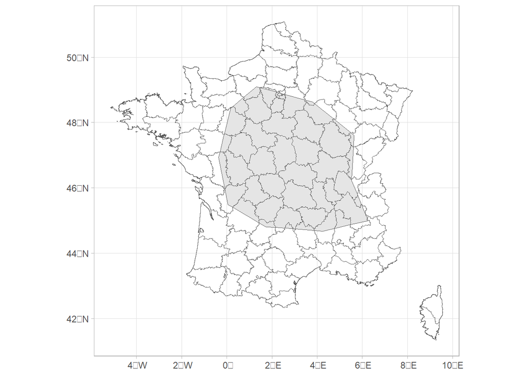

```r
France_sf %>%
  st_intersection(pol_sf) %>%
  ggplot()+
  geom_sf(data = France_sf, fill=NA)+
  geom_sf()+
  theme_light()
```

## Exercise 1

1. Download the data of BELGIUM Level 2
2. Load landuse file “be_osm_lu_red_v3.shp”. The file is in Session 3 folder
3. Compute the total area of each land use class within each administrative level
4. Plot the results. Hint:use ggplot2 library
5. Spatial plot. Hint: use the function dcast
6. Prepare a dynamic plot the results